# Git and GitLab

**This document is particularly important if you follow the RStudio or the Org-Mode path.** **If you follow the Jupyter path, it can be ignored at first** **as we have closely integrated Jupyter and GitLab in the context of this MOOC.**

So far, you only used git via the web interface from the GitLab we deployed for the MOOC: https://app-learninglab.inria.fr/gitlab/

If you access this link from the FUN platform, you do not have to authenticate and you can readily read and modify all your files. This is very convenient but in most cases, you will want to have your own local copy of the repository and you will have to synchronize your local copy with the remote GitLab one. To propagate your modifications, you will obviously have to authenticate yourself on GitLab.

This document describes the software you need to have installed on your machine and how to handle authentication. The "Configuring Git" section is illustrated in a [video tutorial](https://www.fun-mooc.fr/courses/course-v1:inria+41016+session01bis/jump_to_id/7508aece244548349424dfd61ee3ba85) (in French).

Please read all these instructions carefully, in particular the one on "Configuring your password on GitLab".

## Installing Git

### Linux (Debian, Ubuntu)

We provide here only instructions for Debian-based distributions. Feel free to contribute to this document to provide up-to-date information for other distributions (e.g., RedHat, Fedora).

Run (as root):

```bash
apt-get update ; apt-get install git
```

### Mac OSX and Windows

- Download and install Git from the [Git website](https://git-scm.com/downloads).
- Optional Git clients (should not be needed if you work within RStudio):
  - [SourceTree](https://www.sourcetreeapp.com/)
  - [GitHub Desktop](https://desktop.github.com/)

    > [Apparently](https://github.com/desktop/desktop/issues/852), this works with GitLab and https.

## Configuring Git

### Telling Git who you are: Name and Email

1. Open terminal.
2. Set a Git username and email:

   ```bash
   git config --global user.name "Mona Lisa"
   git config --global user.email "email@example.com"
   ```

3. Confirm that you have set the Git username correctly:

   ```bash
   git config --global user.name
   git config --global user.email
   ```

   ```
   Mona Lisa
   email@example.com
   ```

### Dealing with proxies

You may be behind a proxy, in which case you may have trouble cloning or fetching from a remote repository or you may get an error like `unable to access ... Couldn't resolve host ...`

In such case, consider something like this:

```bash
git config --global http.proxy http://proxyUsername:proxyPassword@proxy.server.com:port
```

The `proxyPassword` will be stored in plain text (unencrypted) in your `.gitconfig` file, which you may not want. In that case, remove it from the URL and you will be prompted for it every time it is needed.

### Getting your default password on GitLab (and possibly changing it)

**Warning (Jupyter users) :** changing your default Gitlab password will prevent you from committing in Jupyter. You will have to do the extra step of changing your `~/.git-credentials` in the Jupyter environment (possibly several times).

1. Get your default password using the [Gitlab credentials retrieval tool](https://app-learninglab.inria.fr/jupyterhub/services/password) as described on the [corresponding resource](https://www.fun-mooc.fr/courses/course-v1:inria+41016+session01bis/jump_to_id/7508aece244548349424dfd61ee3ba85).

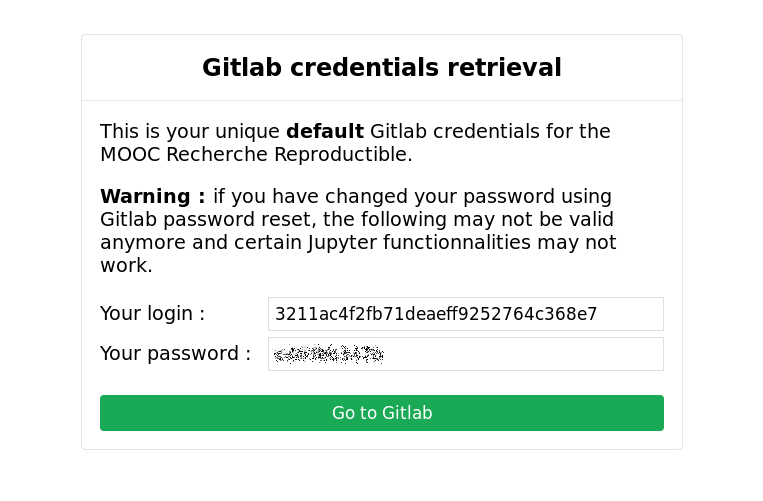

   The first long and ugly character sequence is your GitLab login/id. It is easy to find once you are logged on gitlab. The second one however is your password and this webpage is the only place where you can find it. We used the FUN authentification mechanism to propagate your credentials so only you can have access to it. You'll need to use this password when trying to propagate some modifications from your computer to GitLab.

   *Note: You have to access this webpage from the FUN platform otherwise you may get a 405 error* *when trying to direcly open https://app-learninglab.inria.fr/jupyterhub/services/password.*

[figure not shown]

2. Access [GitLab](https://www.fun-mooc.fr/courses/course-v1:inria+41016+session01bis/xblock/block-v1:inria+41016+session01bis+type@lti+block@05a0ce425f1741e5bee5049040f70529/handler/preview_handler).

   *Note: Again, you have to access Gitlab from the FUN platform otherwise you may get a 405 error* *when trying to direcly open https://app-learninglab.inria.fr/gitlab/users/sign_in*.
3. Click on the first `Sign in` button (alternatively, you can the login/password you just retrieved and use the second `Sign in` button).

[figure not shown]

4. If you wish to modify your password, you should go to `Account > Settings > Password` and define your password using the default password you just retrieved. Again, if you use the Jupyter notebooks we have deployed for the MOOC, remember that changing your default Gitlab password will prevent you from committing in Jupyter. You will have to do the extra step of changing your Jupyter `~/.git-credentials` through a Jupyter console (see next section).

[figure not shown]

### Remembering your password locally

If you clone your repository by simply pasting the GitLab URL, you will be prompted for your login and your password every time you want to propagate your local modifications, which is tedious. This is why you should ask git to remember your login and password as follows

```bash
git config --global credential.helper cache                  # remember my password
git config --global credential.helper "cache --timeout=3600" # for one hour at most
```

With this setup, you will be prompted for your password but it will be cached in memory and they will not be asked again before an hour. You may want to read [these instructions](https://stackoverflow.com/questions/5343068/is-there-a-way-to-skip-password-typing-when-using-https-on-github) to better understand how all this works.

If you want your password to be permanently remembered, you should use this command

```bash
git config credential.helper store
```

Your password will be then stored in a `.git-credentials` file in plain text. On a perfectly secured machine, it may be fine… or not… ;) Use it at your own risk.

### Optional: authenticating through SSH

There are two ways of authenticating and synchronizing your local repository with GitLab: through HTTPS or through SSH. The first one is what was just described and does not require any particular software installation on your machine so this is what I recommend for this MOOC. Yet, I like the second one better (although is may seem a bit more technical), which is why I describe it here. It consists in installing SSH, creating a pair or private/public keys, and uploading your SSH public key on GitLab. This section provides with information on how to do this.

#### Installing SSH

- Linux (Debian, Ubuntu)

  We provide here only instructions for debian-based distributions. Feel free to contribute to this document to provide up-to-date information for other distributions (e.g., RedHat, Fedora).

  Run (as root):

  ```bash
  apt-get update ; apt-get install openssh-client
  ```

- macOS

  You do not have anything to do as it is installed by default.
- Windows

  You should install the [Putty](https://www.ssh.com/ssh/putty/windows/) client. Once it is installed, look for the section on [generating an SSH key](https://www.ssh.com/ssh/putty/windows/puttygen).

#### Setting up SSH on GitLab

Here are [all the official explanations on how to set up your SSH key on GitLab](https://docs.gitlab.com/ee/ssh/). Alternatively, you may also want to have a look at this video:

[video not shown]

## Using Git through the command line to synchronize your local files with Gitlab

This section describes a generic (through the command line) way to synchronize your local files with Gitlab. You will not need this if you follow the Jupyter path. If you follow the RStudio path, all these operations can be done through RStudio and you may want to read the corresponding instructions. If you follow the Org-Mode path, all these operations can be done through Magit and you may want to read the corresponding instructions.

Here are other ways to learn Git through the command line:

- The [Software Carpentry git tutorial](http://swcarpentry.github.io/git-novice/)
- The (freely available) Pro Git book ([in English](https://git-scm.com/book/en/v2) or [in French](https://git-scm.com/book/fr/v2)). Reading the first two chapters is enough to get a good start.
- [Learn Git Branching](https://learngitbranching.js.org/) will allow to interactively learn Git and to understand with branches.

Now, let's start!

1. Obtain the repository URL

[figure not shown]

2. Cloning the repository

   ```bash
   cd /the/directory/where/you/want/to/clone/your/repository
   git clone https://app-learninglab.inria.fr/gitlab/xxx/mooc-rr.git
   ```

   Alternatively, you may want to indicate now your login although I rather suggest you follow the *Remembering your password locally* instructions:

   ```bash
   git clone https://xxx@app-learninglab.inria.fr/gitlab/xxx/mooc-rr.git
   ```

   Now a directory `mooc-rr` has been created on your computer.
3. Inspect the repository

   ```bash
   cd mooc-rr
   ls # (Unix)
   dir # (Windows)
   ```

4. Synchronizing to GitLab

   You should indicate which files to track (`git add`) and commit them locally (`git commit`) before they can be transfered (`git push`) to GitLab. The `git status` will indicate you whether files are tracked/modified/committed/…

   Let's assume you just created a `fichier.txt` file on the top of the `mooc-rr` directory.

[figure not shown]

   ```bash
   git status
   ```

[figure not shown]

   ```bash
   git add fichier.txt
   git status
   ```

[figure not shown]

   ```bash
   git commit -m "message commit"
   ```

[figure not shown]

   ```bash
   git status
   ```

   The file can then be transfered to GitLab:

   ```bash
   git push
   ```

   At this point, git will as you about your login/password unless you followed the previous *Remembering your password locally* instructions.

   N.B.: you will not be allowed to propagate your modifications to GitLab if other modifications (e.g., from someone else) have been propagated in between

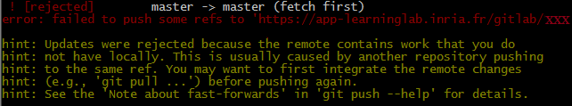

5. Synchronizing from Gitlab: to avoid the previous problem, you need to fetch the remote GitLab modifications first and apply them locally.

   ```bash
   git pull
   ```

   Only then will you be able to `git push`.